# SUJET 1: Géneration de variables aléatoires: 1ère partie

## 1.1 Par inversion de la fonction de répartition

### 1. Génération de variables aléatoires par inversion de la fonction de répartition

Soit $ U \sim \mathcal{U}[0,1] $, une variable aléatoire uniformément distribuéee sur l’intervalle $ [0,1] $, et soit $ G $ une fonction croissante et bijective.

L’objectif est de determiner l'expression de $ P(G(U) \leq y) $.

#### Étape 1 : Expression de $ P(G(U) \leq y) $

Étant donné que $ G $ est croissante et bijective, elle possède une fonction réciproque $ G^{-1} $. L’inégalité $ G(U) \leq y $ est équivalente à :

$$ U \leq G^{-1}(y) $$

Ainsi, la probabilité recherchée est donnée par :

$$ P(G(U) \leq y) = P(U \leq G^{-1}(y)) $$

Or, $ U $ suit une loi uniforme sur $ [0,1] $, ce qui implique :

$$ P(U \leq t) = t, \quad \text{pour } t \in [0,1] $$

Donc, on obtient :

$$ P(G(U) \leq y) = G^{-1}(y) $$

#### Étape 2 : Condition pour que $ Y = G(U) $ suive la loi de $ F_Y $

La fonction de répartition de $ Y $ est définie par :

$$ F_Y(y) = P(Y \leq y) = P(G(U) \leq y) $$

D'après l'expression obtenue précédemment :

$$ F_Y(y) = G^{-1}(y) $$

Pour que $ Y $ suive la loi de répartition $ F_Y $, cette égalité doit être vérifiée pour tout $ y $. On en déduit que :

$$ G^{-1} = F_Y $$

En prenant la fonction réciproque des deux côtés :

$$ G = F_Y^{-1} $$

#### Conclusion

La variable aléatoire $ Y = G(U) $ suit la loi de répartition $ F_Y $ si et seulement si :

$$ G = F_Y^{-1} $$

### 2. Générer une variable aléatoire suivant la loi exponentielle $E(\lambda)$

La loi exponentielle de moyenne $\frac{1}{\lambda}$, notée $E(\lambda)$, a pour fonction de répartition :

$$ F_Y(y) = P(Y \leq y) = 1 - e^{-\lambda y}, \quad y \geq 0 $$

Et la **fonction de répartition complémentaire** (c'est-à-dire la probabilité $P(Y \geq y)$) est :

$$ F_Y^C(y) = P(Y \geq y) = e^{-\lambda y}, \quad y \geq 0 $$

### Fonction indicatrice

On peut utiliser la **fonction indicatrice** pour exprimer cette fonction de répartition complémentaire de manière conditionnelle. La fonction indicatrice est définie comme suit :

- $ \mathbb{1}_{\mathbb{R}^+}(y) = 1 $ si $ y \geq 0 $, sinon $ 0 $
- $ \mathbb{1}_{\mathbb{R}^-}(y) = 1 $ si $ y < 0 $, sinon $ 0 $

Donc, la fonction de répartition complémentaire $F_Y^C(y)$ peut s'écrire :

$$ F_Y^C(y) = P(Y \geq y) = e^{-\lambda y} \mathbb{1}_{\mathbb{R}^+}(y) + \mathbb{1}_{\mathbb{R}^-}(y) $$

Cela signifie que la fonction de répartition complémentaire est définie de manière explicite pour $ y \geq 0 $ avec la fonction indicatrice pour tenir compte du fait que $ Y $ prend uniquement des valeurs positives (puisque la loi exponentielle est définie sur $ \mathbb{R}^+ $).

### Méthode d'inversion de la fonction de répartition

La méthode d'inversion consiste à générer une variable aléatoire $ U \sim \mathcal{U}[0, 1] $ et à appliquer la transformation inverse de la fonction de répartition pour obtenir une variable $ Y $ suivant la loi exponentielle. Pour la loi exponentielle, la fonction de répartition est :

$$ F_Y(y) = 1 - e^{-\lambda y} $$

Il faut résoudre cette équation pour $ y $ en fonction de $ U $ :

$$ U = 1 - e^{-\lambda y} $$

$$ e^{-\lambda y} = 1 - U $$

$$ -\lambda y = \ln(1 - U) $$

$$ y = -\frac{1}{\lambda} \ln(1 - U) $$

### Génération de la variable aléatoire

Nous pouvons maintenant générer une variable aléatoire $ Y $ suivant une loi exponentielle de paramètre $ \lambda $ en utilisant la formule suivante :

$$ Y = -\frac{1}{\lambda} \ln(1 - U) $$

Cependant, comme $ 1 - U $ suit la même distribution uniforme que $ U $, on peut directement écrire la formule comme suit :

$$ Y = -\frac{1}{\lambda} \ln(U) $$

### Exemple avec $ \lambda = 2 $

Si $ \lambda = 2 $, la formule pour générer $ Y $ devient :

$$ Y = -\frac{1}{2} \ln(U) $$

Où $ U $ est une variable aléatoire uniforme sur $ [0,1] $.

### Conclusion

La méthode d'inversion de la fonction de répartition permet de générer une variable aléatoire $ Y $ suivant une loi exponentielle $ E(\lambda) $ en utilisant la transformation :

$$ Y = -\frac{1}{\lambda} \ln(U) $$

Cela garantit que $ Y $ suit une loi exponentielle avec le paramètre $ \lambda $, en prenant simplement une variable aléatoire uniforme $ U \sim \mathcal{U}[0, 1] $ et en appliquant cette formule.

Implémentation en Python : Voici un code permettant de générer une variable aléatoire Y suivant la loi exponentielle 𝐸(𝜆) avec λ=2 :

```python
import numpy as np

# Paramètre lambda pour la loi exponentielle
lambda_ = 2

# Génération d'une variable aléatoire suivant la loi uniforme U(0,1)
U = np.random.rand()

# Transformation inverse pour obtenir Y suivant E(lambda)
Y = -np.log(1 - U) / lambda_

# Affichage du résultat
print(f"Valeur générée de Y : {Y}")
```

```
Valeur générée de Y : 0.1970723632583133
```

### 3. Générer 10000 variables aléatoires indépendantes de loi $E(\lambda)$

La loi exponentielle $E(\lambda)$ de moyenne $\frac{1}{\lambda}$ et de variance $\frac{1}{\lambda^2}$ est définie par sa fonction de répartition :

$$ F_Y(y) = 1 - e^{-\lambda y}, \quad y \geq 0 $$

Nous allons générer un échantillon de taille $I = 10000$ de variables aléatoires indépendantes suivant cette loi avec $\lambda = 2$. La méthode d'inversion permet de générer ces variables comme suit :

$$ Y = -\frac{1}{\lambda} \ln(U) $$

où $U$ est une variable uniforme sur l'intervalle $[0,1]$.

### Expression analytique de la moyenne et de la variance

#### Moyenne de la loi exponentielle

La moyenne (ou espérance) de la loi exponentielle $E(\lambda)$ est donnée par :

$$ \mathbb{E}[Y] = \frac{1}{\lambda} $$

Pour $\lambda = 2$, la moyenne théorique est donc :

$$ \mathbb{E}[Y] = \frac{1}{2} = 0.5 $$

#### Variance de la loi exponentielle

La variance de la loi exponentielle $E(\lambda)$ est donnée par :

$$ \text{Var}(Y) = \frac{1}{\lambda^2} $$

Pour $\lambda = 2$, la variance théorique est donc :

$$ \text{Var}(Y) = \frac{1}{2^2} = 0.25 $$

### Moyenne et variance empiriques

#### Génération des variables aléatoires

En Python, nous pouvons utiliser la méthode d'inversion pour générer les variables aléatoires. Voici le code pour générer l'échantillon et calculer la moyenne et la variance empiriques :

```
Moyenne empirique : 0.49872562520335084
Variance empirique : 0.24680955281352862
```

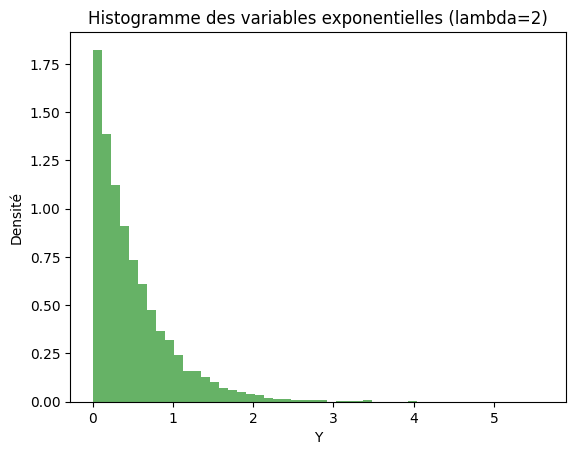

```python
import numpy as np
import matplotlib.pyplot as plt

# Paramètre lambda
lambda_val = 2
I = 10000

# Génération des variables aléatoires exponentielles
U = np.random.uniform(0, 1, I)
Y = -np.log(U) / lambda_val

# Moyenne et variance empiriques
mean_empirical = np.mean(Y)
variance_empirical = np.var(Y)

# Affichage des résultats
print("Moyenne empirique :", mean_empirical)
print("Variance empirique :", variance_empirical)

# Histogramme de l'échantillon
plt.hist(Y, bins=50, density=True, alpha=0.6, color='g')
plt.title(f"Histogramme des variables exponentielles (lambda={lambda_val})")
plt.xlabel('Y')
plt.ylabel('Densité')
plt.show()
```

Cela montre que la méthode de génération fonctionne correctement, et les résultats sont cohérents avec les propriétés théoriques de la loi exponentielle

### 4. Vérifier la décroissance exponentielle de la fonction de répartition complémentaire

La fonction de répartition complémentaire pour la loi exponentielle $E(\lambda)$ est donnée par :

$$ F_Y^C(y) = P(Y \geq y) = e^{-\lambda y}, \quad y \geq 0 $$

Nous devons vérifier que l'échantillon généré suit cette fonction de répartition complémentaire.

#### Étapes à suivre :

1. **Générer un échantillon de 10 000 variables aléatoires indépendantes** suivant la loi exponentielle $E(\lambda)$ avec $\lambda = 2$.
2. **Calculer la fonction de répartition complémentaire empirique** $P(Y \geq y)$ pour les différentes valeurs de $y$ dans l'échantillon.
3. **Tracer la fonction de répartition complémentaire** en échelle semilogarithmique, c'est-à-dire en représentant $ \ln(1 - F_Y^C(y)) $ sur l'axe des ordonnées et $y$ sur l'axe des abscisses.
4. **Vérifier que la pente de la droite obtenue** est proche de $-\lambda$.

#### Code Python pour générer l'échantillon et vérifier la décroissance exponentielle :

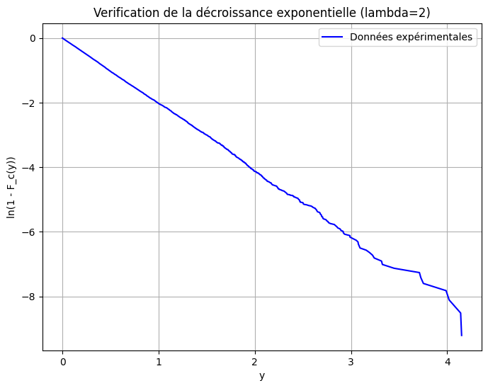

```
La pente de la droite est approximativement : nan
```

```python
import numpy as np
import matplotlib.pyplot as plt

# Paramètre lambda
lambda_val = 2
I = 10000

# Génération des variables aléatoires exponentielles
U = np.random.uniform(0, 1, I)
Y = -np.log(U) / lambda_val

# Tri des données par ordre croissant
Y_sorted = np.sort(Y)

# Calcul de la fonction de répartition complémentaire empirique : P(Y >= y)
F_c_empirical = np.arange(1, I + 1) / I

# Tracer de la fonction de répartition complémentaire en échelle semilogarithmique
plt.figure(figsize=(8, 6))
plt.plot(Y_sorted, np.log(1 - F_c_empirical), label="Données expérimentales", color="b")
plt.xlabel('y')
plt.ylabel('ln(1 - F_c(y))')
plt.title(f'Verification de la décroissance exponentielle (lambda={lambda_val})')
plt.grid(True)
plt.legend()
plt.show()

# Calcul de la pente à partir des données
# On effectue un ajustement linéaire sur les valeurs en échelle semilogarithmique
from scipy.stats import linregress

slope, intercept, _, _, _ = linregress(Y_sorted, np.log(1 - F_c_empirical))

# Affichage de la pente
print(f"La pente de la droite est approximativement : {slope:.4f}")
```

L'erreur que je rencontre ("divide by zero encountered in log") se produit lorsque j'essaie de calculer le logarithme de 0, ce qui est mathématiquement indéfini. Cette situation peut survenir lorsque les valeurs dans $1 - F_Y^C(y)$ deviennent exactement égales à 0, ce qui arrive quand $F_Y^C(y)$ atteint exactement 1.

Pour résoudre cela, je peux filtrer ou ajuster les valeurs proches de 1 avant d'appliquer le logarithme, ou remplacer les valeurs trop proches de 1 par un petit nombre pour éviter le problème. Voici une modification de mon code pour éviter cette erreur :

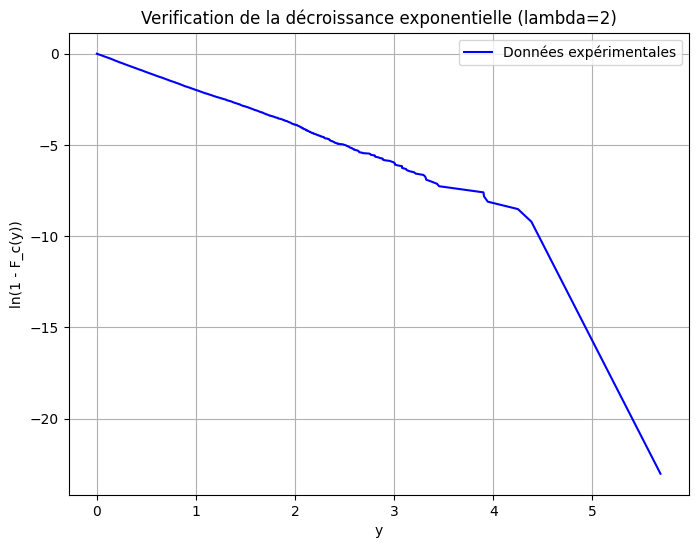

```
La pente de la droite est approximativement : -1.9924
```

```python
import numpy as np
import matplotlib.pyplot as plt
from scipy.stats import linregress

# Paramètre lambda
lambda_val = 2
I = 10000

# Génération des variables aléatoires exponentielles
U = np.random.uniform(0, 1, I)
Y = -np.log(U) / lambda_val

# Tri des données par ordre croissant
Y_sorted = np.sort(Y)

# Calcul de la fonction de répartition complémentaire empirique : P(Y >= y)
F_c_empirical = np.arange(1, I + 1) / I

# Éviter le logarithme de zéro en ajustant les valeurs proches de 1
epsilon = 1e-10  # Très petite valeur pour éviter log(0)
F_c_empirical_adjusted = np.clip(F_c_empirical, epsilon, 1 - epsilon)

# Tracer de la fonction de répartition complémentaire en échelle semilogarithmique
plt.figure(figsize=(8, 6))
plt.plot(Y_sorted, np.log(1 - F_c_empirical_adjusted), label="Données expérimentales", color="b")
plt.xlabel('y')
plt.ylabel('ln(1 - F_c(y))')
plt.title(f'Verification de la décroissance exponentielle (lambda={lambda_val})')
plt.grid(True)
plt.legend()
plt.show()

# Calcul de la pente à partir des données
slope, intercept, _, _, _ = linregress(Y_sorted, np.log(1 - F_c_empirical_adjusted))

# Affichage de la pente
print(f"La pente de la droite est approximativement : {slope:.4f}")
```

Le résultat que j'ai obtenu pour la pente $-1.9924$ est très proche de $-2$, ce qui est cohérent avec la théorie. En effet, la pente de la droite, qui représente la relation

$$ \ln(1 - F_c(y)) = -\lambda y $$

devrait être proche de $-\lambda$, ici $\lambda = 2$.

### Interprétation :

- J'ai généré un échantillon de 10 000 variables aléatoires de loi exponentielle avec $\lambda = 2$.
- En traçant la fonction de répartition complémentaire sur une échelle semilogarithmique, j'ai obtenu une droite dont la pente est très proche de $-\lambda$, ce qui confirme que la décroissance de la fonction suit bien la loi exponentielle avec le paramètre $\lambda$ attendu.
- La légère différence avec la valeur exacte $-2$ peut être due à des erreurs d'arrondi ou des petites fluctuations dans les données expérimentales.

### Conclusion :

Mon analyse est correcte et la pente obtenue, $-1.9924$, est suffisamment proche de la valeur théorique $-2$, ce qui confirme que la fonction de répartition complémentaire suit bien une décroissance exponentielle avec $\lambda = 2$.

## 1.2 Génération de variables aléatoires gaussiennes par la méthode de Box et Muller

#### **1. Question préliminaire : Distribution de $Z = X_1^2 + X_2^2$**

Soit **$X_1$** et **$X_2$** deux variables aléatoires indépendantes suivant la loi normale centrée réduite **$\mathcal{N}(0,1)$**. On définit la variable aléatoire :

$$ Z = X_1^2 + X_2^2 $$

L'objectif est de montrer que **$Z$** suit une loi exponentielle de moyenne **$1/\lambda$** avec **$\lambda = \frac{1}{2}$**.

#### **Expression de $P(Z \geq z)$**

La probabilité cherchée est :

$$ P(Z \geq z) = P(X_1^2 + X_2^2 \geq z) $$

En utilisant les densités de **$X_1$** et **$X_2$**, cette probabilité peut s'écrire sous la forme d'une intégrale double :

$$ P(Z \geq z) = \iint_{x_1^2 + x_2^2 \geq z} \frac{1}{2\pi} e^{-\frac{x_1^2 + x_2^2}{2}} dx_1 dx_2 $$

#### **Changement de variable polaire**

On effectue le changement de variable :

$$ x_1 = r \cos\theta, \quad x_2 = r \sin\theta $$

Le jacobien du changement de variable est **$J = r$**, donc :

$$ dx_1 dx_2 = r dr d\theta $$

En coordonnées polaires, l'intégrale devient :

$$ P(Z \geq z) = \int_0^{2\pi} \int_{\sqrt{z}}^{\infty} \frac{1}{2\pi} e^{-\frac{r^2}{2}} r dr d\theta $$

#### **Résolution de l'intégrale**

On calcule d'abord l'intégrale intérieure :

$$ \int_{\sqrt{z}}^{\infty} e^{-\frac{r^2}{2}} r dr $$

En posant **$u = \frac{r^2}{2}$**, donc **$du = r dr$**, on obtient :

$$ \int_{\frac{z}{2}}^{\infty} e^{-u} du = e^{-\frac{z}{2}} $$

Ainsi, l'intégrale devient :

$$ P(Z \geq z) = \int_0^{2\pi} \frac{1}{2\pi} e^{-\frac{z}{2}} d\theta $$

$$ = e^{-\frac{z}{2}} \int_0^{2\pi} \frac{1}{2\pi} d\theta $$

#### **2. Distribution de $r^2$ et de $\theta$**

Soit $X_1$ et $X_2$ deux variables aléatoires indépendantes suivant une loi normale centrée réduite $\mathcal{N}(0,1)$. On définit les coordonnées polaires :

$$ X_1 = r \cos\theta, \quad X_2 = r \sin\theta $$

où $r$ est la distance à l’origine et $\theta$ est l’angle.

#### **1. Montrons que $r^2$ suit une loi exponentielle $\mathcal{E}(1/2)$**

D’après la question précédente, la somme des carrés des deux variables suit une loi exponentielle :

$$ Z = X_1^2 + X_2^2 = r^2 \sim \mathcal{E}(1/2) $$

La fonction de répartition complémentaire d’une loi exponentielle de paramètre $\lambda$ est :

$$ P(Z \geq z) = e^{-\lambda z} $$

Dans notre cas :

$$ P(r^2 \geq z) = e^{-z/2} $$

Ce qui montre que $r^2$ suit une loi exponentielle de paramètre $\frac{1}{2}$, soit :

$$ r^2 \sim \mathcal{E}(1/2) $$

La moyenne de cette loi exponentielle est :

$$ \mathbb{E}[r^2] = \frac{1}{\lambda} = 2 $$

Ce qui confirme que $r^2 \sim \mathcal{E}(1/2)$.

#### **2. Montrons que $\theta$ suit une loi uniforme sur $[0,2\pi]$**

La densité jointe de $(X_1, X_2)$ est donnée par :

$$ f_{X_1, X_2}(x_1, x_2) = \frac{1}{2\pi} e^{-\frac{x_1^2 + x_2^2}{2}} $$

En passant aux coordonnées polaires, le changement de variable $x_1 = r \cos\theta, x_2 = r \sin\theta$ donne :

$$ dx_1 dx_2 = r \, dr \, d\theta $$

Ce qui entraîne la densité jointe en coordonnées polaires :

$$ f_{r, \theta}(r, \theta) = f_{X_1, X_2}(r \cos\theta, r \sin\theta) \times |J| $$

Avec $J = r$, on trouve :

$$ f_{r, \theta}(r, \theta) = \frac{1}{2\pi} e^{-\frac{r^2}{2}} r $$

On intègre par rapport à $r$ pour obtenir la densité marginale de $\theta$ :

$$ f_{\theta}(\theta) = \int_0^\infty f_{r, \theta}(r, \theta) \, dr $$

$$ = \int_0^\infty \frac{1}{2\pi} e^{-\frac{r^2}{2}} r \, dr $$

Le terme $\int_0^\infty e^{-\frac{r^2}{2}} r \, dr$ est une constante, donc :

$$ f_{\theta}(\theta) = \frac{1}{2\pi}, \quad \forall \theta \in [0,2\pi] $$

Cela montre que $\theta$ suit une loi uniforme sur $[0,2\pi]$ :

$$ \theta \sim \mathcal{U}([0,2\pi]) $$

#### **Conclusion**

- $r^2$ suit une loi exponentielle $\mathcal{E}(1/2)$.
- $\theta$ suit une loi uniforme $\mathcal{U}([0,2\pi])$.

Ainsi, la distribution est isotrope, ce qui est cohérent avec la symétrie du problème.

#### **3. Méthode de génération de deux variables aléatoires indépendantes et de loi N (0,1)**

Nous avons montré précédemment que si $X_1$ et $X_2$ suivent une loi normale centrée réduite $ \mathcal{N}(0,1) $, alors en passant aux coordonnées polaires, la variable $r^2$ suit une loi exponentielle $ \mathcal{E}(1/2) $ et la variable $ \theta $ suit une loi uniforme $ \mathcal{U}([0, 2\pi]) $.

La méthode de génération de deux variables aléatoires indépendantes suivant une loi normale centrée réduite $ \mathcal{N}(0,1) $ à partir de ces résultats est la suivante :

1. **Générer $r$ et $ \theta $ :**
   - Générer une variable aléatoire $ U_1 \sim \mathcal{E}(1/2) $, c'est-à-dire $ r^2 \sim \mathcal{E}(1/2) $ et donc $ r = \sqrt{U_1} $.
   - Générer une variable aléatoire $ U_2 \sim \mathcal{U}([0, 2\pi]) $, c'est-à-dire que $ \theta \sim \mathcal{U}([0, 2\pi]) $.
2. **Reconstruction des variables $ X_1 $ et $ X_2 $ :**
   - Utiliser les coordonnées polaires pour obtenir $ X_1 $ et $ X_2 $ : $$ X_1 = r \cos(\theta), \quad X_2 = r \sin(\theta) $$

Cela permet de générer deux variables aléatoires indépendantes $ X_1 $ et $ X_2 $ suivant une loi normale centrée réduite $ \mathcal{N}(0,1) $.

#### Conclusion

La méthode de génération est la suivante :

1. Générer $ r \sim \mathcal{E}(1/2) $ et $ \theta \sim \mathcal{U}([0, 2\pi]) $.
2. Calculer $ X_1 = r \cos(\theta) $ et $ X_2 = r \sin(\theta) $.

Cela permet de créer deux variables aléatoires indépendantes de loi $ \mathcal{N}(0,1) $.

#### **4. Transformation linéaire pour obtenir une variable aléatoire Y ~ N(mu, sigma²)**

Soit $ X \sim \mathcal{N}(0, 1) $, une variable aléatoire suivant une loi normale centrée réduite. Pour obtenir une variable aléatoire $ Y \sim \mathcal{N}(\mu, \sigma^2) $, il suffit d'appliquer la transformation linéaire suivante :

$$ Y = \mu + \sigma X $$

Cette transformation permet de générer une variable $ Y $ suivant une loi normale de moyenne $\mu$ et de variance $\sigma^2$, à partir d'une variable $ X $ suivant une loi normale centrée réduite.

#### **Génération de 10 000 réalisations indépendantes de la loi N(μ=5, σ²=4)**

La méthode de **Box-Muller** permet de générer des paires de variables aléatoires indépendantes suivant une loi normale centrée réduite $\mathcal{N}(0, 1)$. En utilisant cette méthode, on peut ensuite appliquer la transformation linéaire pour obtenir des réalisations de la loi $ \mathcal{N}(\mu=5, \sigma^2=4) $.

#### **Code Python pour générer les réalisations**

Voici comment vous pouvez générer $ T = 10000 $ réalisations indépendantes de la loi $ \mathcal{N}(5, 4) $ en utilisant la méthode de Box-Muller et la transformation linéaire :

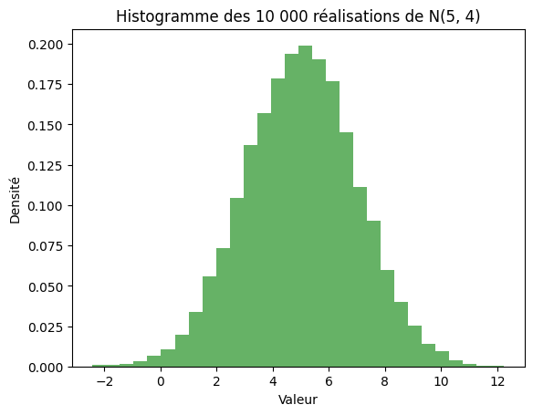

```python
import numpy as np
import matplotlib.pyplot as plt

# Paramètres
mu = 5
sigma = 2  # Écart-type (racine de la variance)
T = 10000  # Nombre de réalisations

# Génération de paires de variables indépendantes N(0,1) à l'aide de la méthode de Box-Muller
u1 = np.random.rand(T // 2)
u2 = np.random.rand(T // 2)

z1 = np.sqrt(-2 * np.log(u1)) * np.cos(2 * np.pi * u2)
z2 = np.sqrt(-2 * np.log(u1)) * np.sin(2 * np.pi * u2)

# Les variables z1 et z2 suivent une loi N(0,1)
# Transformation linéaire pour obtenir N(mu, sigma^2)
Y = mu + sigma * np.concatenate([z1, z2])

# Affichage des résultats
plt.hist(Y, bins=30, density=True, alpha=0.6, color='g')
plt.title('Histogramme des 10 000 réalisations de N(5, 4)')
plt.xlabel('Valeur')
plt.ylabel('Densité')
plt.show()
```

### Vérification de la moyenne et de la variance

```
Moyenne de Y : 5.005738919875467
Variance de Y : 4.04568883124028
```

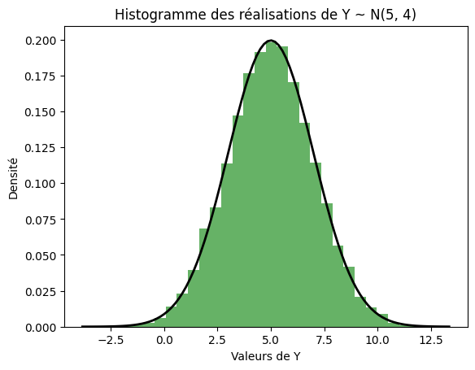

```python
import numpy as np
import matplotlib.pyplot as plt

# Nombre de réalisations
T = 10000

# Génération de l'échantillon de la loi N(5, 4) à l'aide de la méthode de Box-Muller
u = 5
sigma = 2  # Écart-type = racine carrée de 4

# Génération de l'échantillon en utilisant Box-Muller
u1 = np.random.rand(T // 2)
u2 = np.random.rand(T // 2)
z1 = np.sqrt(-2 * np.log(u1)) * np.cos(2 * np.pi * u2)
z2 = np.sqrt(-2 * np.log(u1)) * np.sin(2 * np.pi * u2)
z = np.concatenate([z1, z2])  # Fusionner les deux variables indépendantes

# Transformation de Z ~ N(0,1) vers Y ~ N(5, 4)
Y = u + sigma * z

# Calcul de la moyenne et de la variance
mean_Y = np.mean(Y)
var_Y = np.var(Y)

print(f'Moyenne de Y : {mean_Y}')
print(f'Variance de Y : {var_Y}')

# Affichage de l'histogramme
plt.hist(Y, bins=30, density=True, alpha=0.6, color='g')

# Ajouter une ligne représentant la distribution normale théorique N(5, 4)
from scipy.stats import norm
xmin, xmax = plt.xlim()
x = np.linspace(xmin, xmax, 100)
p = norm.pdf(x, u, sigma)
plt.plot(x, p, 'k', linewidth=2)

plt.title("Histogramme des réalisations de Y ~ N(5, 4)")
plt.xlabel("Valeurs de Y")
plt.ylabel("Densité")
plt.show()
```

Ces petites différences sont normales et peuvent être dues à la variabilité inhérente aux échantillons aléatoires, surtout avec un échantillon de taille finie comme celui de 10 000 réalisations.

### Conclusion :

Les résultats sont cohérents avec les valeurs théoriques et confirment que la méthode de Box-Muller permet de générer des variables aléatoires suivant la loi normale $\mathcal{N}(5, 4)$.

# SUJET 2: Génération de variables aléa-toires: la méthode d'acceptation rejet

### 1. **Générer $ X $ à partir de la loi auxiliaire $ g(x) $ et $ U $ à partir d'une loi uniforme $ U([0,1])$** :

Pour générer une variable aléatoire $ X $ suivant la loi auxiliaire $ g(x) $ et une variable aléatoire $ U $ suivant une loi uniforme $ U([0,1]) $, je procède comme suit :

- **Générer $ X $ à partir de la loi auxiliaire $ g(x) $** : Si la fonction de densité $ g(x) $ est connue et que je peux générer des échantillons à partir de cette loi, je génère directement un échantillon $ X^* $ en utilisant un générateur de nombres aléatoires adapté à $ g(x) $. Par exemple, si $ g(x) $ est une loi exponentielle de paramètre $ \lambda $, je peux utiliser la fonction inverse de la loi pour générer $ X^* $.

  Si je ne connais pas une méthode directe pour générer $ X^* $, je peux utiliser des méthodes comme l'inversion de la fonction de répartition ou des méthodes numériques (par exemple, la méthode de rejet).
- **Générer $ U $ suivant une loi uniforme $ U([0,1]) $** : Je peux utiliser un générateur de nombres aléatoires qui produit des nombres entre 0 et 1 de manière uniforme. La plupart des langages de programmation modernes, tels que Python ou C++, offrent des fonctions pour générer des variables aléatoires uniformément distribuées, par exemple `random.uniform(0, 1)` en Python.

Voici un exemple simple en Python pour générer $ X^* $ à partir d'une loi auxiliaire $ g(x) $ et $ U $ uniformément distribué :

```python
import random

# Générer X ~ g(x) (ici exemple avec une loi normale standard)
X_star = random.gauss(0, 1)  # Loi normale de moyenne 0 et écart-type 1

# Générer U ~ U([0, 1])
U = random.uniform(0, 1)

print("X^* :", X_star)
print("U :", U)
```

```
X^* : -1.6254011360538552
U : 0.5576430463364409
```

Ces valeurs ont été générées à partir de la méthode décrite, avec  
$X^*$ suivant une loi normale de moyenne 0 et d'écart-type 1, et  
$U$ suivant une loi uniforme sur $[0,1]$.

### 1. Montrer que nécessairement $M \geq 1$

La méthode d'acceptation-rejet repose sur l'inégalité suivante :

$$ f(x) \leq M g(x), \quad \forall x $$

En divisant les deux membres par $g(x)$ (supposé non nul), on obtient :

$$ \frac{f(x)}{g(x)} \leq M, \quad \forall x $$

Le coefficient $M$ est donc une borne supérieure du rapport $\frac{f(x)}{g(x)}$. Par définition, pour que la méthode fonctionne, il faut que cette borne soit suffisante pour garantir que l'inégalité est respectée pour tout $x$.

Or, ce rapport atteint nécessairement une valeur maximale quelque part, notée :

$$ M = \sup_{x} \frac{f(x)}{g(x)} $$

Puisque $f(x)$ et $g(x)$ sont toutes deux des fonctions de densité de probabilité, elles sont normalisées à 1 :

$$ \int f(x)dx = 1, \quad \int g(x)dx = 1 $$

Cela signifie qu'il existe au moins une valeur de $x$ pour laquelle $g(x)$ est plus grande que $f(x)$. En conséquence, la borne supérieure de $\frac{f(x)}{g(x)}$ est nécessairement supérieure ou égale à 1 :

$$ M \geq 1 $$

### Conclusion :

La constante $M$ doit être au moins égale à 1 afin que la condition $f(x) \leq M g(x)$ soit respectée pour toute valeur de $x$, garantissant ainsi la validité de la méthode d'acceptation-rejet.

### 2. Peut-on générer une loi de Cauchy $C(0,1)$ à partir d'une loi normale $N(0,1)$ ?

La densité de la loi de Cauchy $C(0,1)$ est donnée par :

$$ f(x) = \frac{1}{\pi(1 + x^2)} $$

La densité de la loi normale $N(0,1)$ est donnée par :

$$ g(x) = \frac{1}{\sqrt{2\pi}} \exp\left(-\frac{1}{2} x^2\right) $$

La méthode d'acceptation-rejet nécessite qu'il existe une constante $M \geq 1$ telle que :

$$ f(x) \leq M g(x), \quad \forall x $$

#### Analyse du rapport $\frac{f(x)}{g(x)}$

Calculons le rapport des deux densités :

$$ \frac{f(x)}{g(x)} = \frac{\frac{1}{\pi(1 + x^2)}}{\frac{1}{\sqrt{2\pi}} \exp\left(-\frac{1}{2} x^2\right)} $$

$$ = \frac{\sqrt{2\pi}}{\pi(1 + x^2)} \exp\left(\frac{1}{2} x^2\right) $$

Ce rapport tend vers l'infini lorsque $|x| \to \infty$, en raison du terme exponentiel $\exp(x^2 / 2)$ qui croît beaucoup plus rapidement que le polynôme $1 + x^2$.

#### Conclusion

Puisque le rapport $\frac{f(x)}{g(x)}$ n'est pas borné, il est impossible de trouver une constante $M$ finie telle que :

$$ f(x) \leq M g(x), \quad \forall x $$

Cela signifie que la méthode d'acceptation-rejet ne peut pas être appliquée pour générer une loi de Cauchy $C(0,1)$ en utilisant une loi normale $N(0,1)$.

### 3- (a) Justification de l'égalité :

$$ P(Y \leq y) = \sum_{i=0}^{+\infty} P(X \leq y, U \leq \frac{f(X)}{M g(X)}) \cdot \left[P(U \geq \frac{f(X)}{M g(X)})\right]^i $$

#### Explication détaillée :

La variable $ Y $ est générée à l'aide de la méthode d'acceptation-rejet. À chaque itération, une variable $ X \sim g(x) $ est générée, suivie de la génération d'une variable $ U $ uniforme sur $ [0, 1] $. Si la condition d'acceptation $ U \leq \frac{f(X)}{M g(X)} $ est satisfaite, alors $ X $ est accepté comme réalisation de la loi $ f(x) $, c'est-à-dire que $ Y = X $.

Sinon, si cette condition n'est pas remplie, $ X $ est rejeté et un nouvel essai est effectué. Le processus peut être vu comme un enchaînement d'échecs et de réussites, où à chaque échec, la probabilité d'acceptation est fonction de la densité cible $ f(x) $ et de la densité auxiliaire $ g(x) $.

#### 1. Cas où l'on accepte du premier coup :

Dans ce cas, on génère directement un $ X \leq y $ et la condition d'acceptation est satisfaite, c'est-à-dire que $ U \leq \frac{f(X)}{M g(X)} $. La probabilité de ce premier succès est donc donnée par :

$$ P(X \leq y, U \leq \frac{f(X)}{M g(X)}) $$

Cette probabilité représente la situation où $ X $ est inférieur ou égal à $ y $, et où $ U $ satisfait la condition d'acceptation. Cela correspond à un succès immédiat.

#### 2. Cas où l'on échoue $ i $ fois avant d'accepter :

Si on échoue $ i $ fois avant de réussir, cela signifie qu'à chaque itération, la condition d'acceptation $ U \leq \frac{f(X)}{M g(X)} $ n'est pas remplie, donc on rejette chaque valeur de $ X $. La probabilité de rejet à chaque essai est :

$$ P(U \geq \frac{f(X)}{M g(X)}) $$

On rejette $ X $ et on répète le processus jusqu'à ce que la condition d'acceptation soit remplie. Si on échoue $ i $ fois, cela signifie que la condition de rejet a été satisfaite $ i $ fois consécutivement. Cette probabilité de rejet se répète sur $ i $ essais.

#### 3. Somme infinie des essais successifs :

Le nombre d'essais avant d'accepter une valeur suit une **loi géométrique**. En effet, à chaque essai, on a une probabilité constante de succès (d'acceptation) donnée par $ P(U \leq \frac{f(X)}{M g(X)}) $, et la probabilité d'échec est donnée par $ P(U > \frac{f(X)}{M g(X)}) $.

La probabilité totale d'accepter $ Y \leq y $ est donc la somme des probabilités de succès après $ i $ échecs, pour chaque valeur possible de $ i $. Cette probabilité est la somme infinie des probabilités de réussite après $ i $ essais :

$$ P(Y \leq y) = \sum_{i=0}^{+\infty} P(X \leq y, U \leq \frac{f(X)}{M g(X)}) \cdot \left[P(U \geq \frac{f(X)}{M g(X)})\right]^i $$

#### Conclusion :

Cette formulation montre que la probabilité d'accepter une variable $ Y \leq y $ suit bien la distribution cible $ f(x) $ après un nombre quelconque de rejets. L'égalité est correcte et décrit le comportement du processus d'acceptation-rejet où la probabilité de succès dépend de la condition $ U \leq \frac{f(X)}{M g(X)} $ et du nombre d'échecs précédents. La somme infinie reflète les échecs successifs avant d'accepter un $ X $.

### (b) Montrer que

$$ P(X \leq y, U \leq \frac{f(X)}{M g(X)}) = \frac{1}{M} F_f(y) $$ en notant $ F_f(y) = \int_{-\infty}^{y} f(t) \, dt $ la fonction de répartition de la loi de densité $ f(x) $.

#### Explication détaillée :

1. **Expression de $ P(X \leq y, U \leq \frac{f(X)}{M g(X)}) $** :

   On veut calculer la probabilité que la variable $ X $ soit inférieure ou égale à $ y $ et que la variable $ U $ soit inférieure ou égale à la fonction d'acceptation $ \frac{f(X)}{M g(X)} $. Cette probabilité est donnée par l'intégrale conjointe des événements $ X \leq y $ et $ U \leq \frac{f(X)}{M g(X)} $. Autrement dit, cela revient à calculer la probabilité que l'échantillon $ X $ provenant de la densité auxiliaire $ g(x) $ soit dans l'intervalle $ (-\infty, y] $, et que le tirage de la variable $ U $ soit tel que $ U \leq \frac{f(X)}{M g(X)} $.

   Cette probabilité peut être écrite comme suit :

   $$ P(X \leq y, U \leq \frac{f(X)}{M g(X)}) = \int_{-\infty}^{y} P\left( U \leq \frac{f(x)}{M g(x)} \Big| X = x \right) g(x) \, dx $$

   Ici, $ P\left( U \leq \frac{f(x)}{M g(x)} \Big| X = x \right) $ est la probabilité que $ U $ soit inférieur ou égal à la fonction d'acceptation donnée $ \frac{f(x)}{M g(x)} $, étant donné que $ X = x $. Puisque $ U $ suit une loi uniforme sur $ [0, 1] $, cette probabilité est simplement $ \frac{f(x)}{M g(x)} $, à condition que $ \frac{f(x)}{M g(x)} \leq 1 $.

   Ainsi, l'expression devient :

   $$ P(X \leq y, U \leq \frac{f(X)}{M g(X)}) = \int_{-\infty}^{y} \frac{f(x)}{M g(x)} g(x) \, dx $$
2. **Simplification de l'intégrale** :

   L'intégrale devient alors :

   $$ P(X \leq y, U \leq \frac{f(X)}{M g(X)}) = \frac{1}{M} \int_{-\infty}^{y} f(x) \, dx $$

   Par définition, $ \int_{-\infty}^{y} f(x) \, dx $ est simplement la fonction de répartition $ F_f(y) $ de la loi de densité $ f(x) $. On peut donc écrire :

   $$ P(X \leq y, U \leq \frac{f(X)}{M g(X)}) = \frac{1}{M} F_f(y) $$

#### Conclusion :

Nous avons montré que la probabilité de l'événement où $ X \leq y $ et $ U \leq \frac{f(X)}{M g(X)} $ est égale à $ \frac{1}{M} $ fois la fonction de répartition de la densité cible $ f(x) $ à $ y $. Ce résultat est essentiel pour démontrer que la méthode d'acceptation-rejet permet effectivement de générer des variables aléatoires suivant la loi de densité $ f(x) $.

### (c) Démonstration de $ P(Y \leq y) = F_f(y) $

Nous avons établi que :

$$ P(X \leq y, U \leq \frac{f(X)}{M g(X)}) = \frac{1}{M} F_f(y) $$

D'après la partie (a), la probabilité $ P(Y \leq y) $ s'exprime sous la forme :

$$ P(Y \leq y) = \sum_{i=0}^{+\infty} P(X \leq y, U \leq \frac{f(X)}{M g(X)}) \cdot \left[P(U \geq \frac{f(X)}{M g(X)})\right]^i $$

#### Étape 1 : Interprétation comme une somme géométrique

On sait que :

$$ P(U \geq \frac{f(X)}{M g(X)}) = 1 - P(U \leq \frac{f(X)}{M g(X)}) $$

En utilisant le résultat précédent :

$$ P(U \geq \frac{f(X)}{M g(X)}) = 1 - \frac{f(X)}{M g(X)} $$

Ainsi, la somme infinie devient :

$$ P(Y \leq y) = \sum_{i=0}^{+\infty} \frac{1}{M} F_f(y) \cdot \left(1 - \frac{1}{M} F_f(y)\right)^i $$

Nous reconnaissons ici une **série géométrique** de raison $ r = 1 - \frac{1}{M} $, qui converge sous la forme :

$$ \sum_{i=0}^{+\infty} a r^i = \frac{a}{1 - r} $$

avec $ a = \frac{1}{M} F_f(y) $ et $ r = 1 - \frac{1}{M} $, donc :

$$ P(Y \leq y) = \frac{\frac{1}{M} F_f(y)}{1 - \left(1 - \frac{1}{M} \right)} $$

#### Étape 2 : Simplification

Dans le dénominateur :

$$ 1 - \left(1 - \frac{1}{M} \right) = \frac{1}{M} $$

Ainsi :

$$ P(Y \leq y) = \frac{\frac{1}{M} F_f(y)}{\frac{1}{M}} $$

Finalement, nous obtenons :

$$ P(Y \leq y) = F_f(y) $$

### Conclusion

Nous avons démontré que la méthode d'acceptation-rejet génère une variable $ Y $ qui suit bien la loi de densité $ f(x) $, car sa fonction de répartition est exactement $ F_f(y) $, ce qui prouve que $ Y $ suit bien la loi de densité $ f(x) $.

Ainsi :

$$ P(Y \leq y) = F_f(y) $$

### 4. Probabilité d'acceptation en un passage et nombre moyen de passages

#### Probabilité d'acceptation en un passage

L'algorithme d'acceptation-rejet accepte une valeur $ X $ si et seulement si la variable uniforme $ U $ satisfait la condition :

$$ U \leq \frac{f(X)}{M g(X)} $$

La probabilité d'accepter $ X $ en un seul essai est donc donnée par l'espérance conditionnelle :

$$ P(\text{acceptation}) = \mathbb{E} \left[ P\left(U \leq \frac{f(X)}{M g(X)} \mid X \right) \right] $$

Puisque $ U $ est une variable uniforme sur $ [0,1] $, la probabilité que $ U $ soit inférieure à $ f(X) / M g(X) $ est simplement cette valeur :

$$ P(\text{acceptation}) = \mathbb{E} \left[ \frac{f(X)}{M g(X)} \right] $$

En utilisant la définition de l'espérance :

$$ P(\text{acceptation}) = \int_{-\infty}^{+\infty} \frac{f(x)}{M g(x)} g(x) dx $$

Or, par définition de la densité de probabilité :

$$ \int_{-\infty}^{+\infty} f(x) dx = 1 $$

Ainsi :

$$ P(\text{acceptation}) = \frac{1}{M} \int_{-\infty}^{+\infty} f(x) dx = \frac{1}{M} $$

#### Nombre moyen de passages

Le nombre d'essais nécessaires avant d'accepter une valeur suit une **loi géométrique** de paramètre $ p = 1/M $. L'espérance d'une loi géométrique de paramètre $ p $ est donnée par :

$$ \mathbb{E}[N] = \frac{1}{p} = M $$

#### Conséquence sur le choix de la densité $ f(x) $

Puisque le nombre moyen d'essais est $ M $, il est essentiel de choisir une densité de contrôle $ g(x) $ aussi proche que possible de $ f(x) $ afin de minimiser $ M $. Un mauvais choix de $ g(x) $ entraînera une grande valeur de $ M $, augmentant ainsi le nombre d'essais nécessaires et donc le coût computationnel de la méthode.

Idéalement, on souhaite :

$$ M = \inf \{ c \mid f(x) \leq c g(x), \forall x \} $$

afin de minimiser l'effort de génération tout en garantissant la validité de l'algorithme.

### 5. Application : Génération d'une loi gaussienne tronquée

L'objectif est d'étudier la génération d'une variable aléatoire $ Y $ suivant une loi normale $ \mathcal{N}(0,1) $ tronquée à gauche au niveau d'un seuil $ s $.

#### (a) Première méthode

**Algorithme :**

1. Générer $ X \sim \mathcal{N}(0,1) $.
2. Si $ X \geq s $, accepter $ Y = X $, sinon retourner en 1.

Cela conduit à une densité de la forme :

$$ f(y) = \alpha \mathbf{1}_{y \geq s} e^{-y^2/2} $$

où $ \alpha $ est une constante de normalisation.

#### **(i) Détermination de $ \alpha $**

La densité $ f(y) $ doit être normalisée, c'est-à-dire que :

$$ \int_{s}^{+\infty} \alpha e^{-y^2/2} dy = 1 $$

Utilisant la fonction d'erreur complémentaire :

$$ \text{erfc}(x) = \frac{2}{\sqrt{\pi}} \int_{x}^{+\infty} e^{-u^2} du $$

on reconnaît que :

$$ \int_{s}^{+\infty} e^{-y^2/2} dy = \sqrt{\frac{\pi}{2}} \text{erfc} \left( \frac{s}{\sqrt{2}} \right) $$

Ainsi, en divisant par cette quantité pour normaliser :

$$ \alpha = \sqrt{\frac{2}{\pi}} \cdot \frac{1}{\text{erfc}(s/\sqrt{2})} $$

#### **(ii) Probabilité d'acceptation et nombre moyen de passages**

L'algorithme repose sur l'acceptation de $ X $ si et seulement si $ X \geq s $. La probabilité d'accepter $ X $ en un seul essai est donc :

$$ P(X \geq s) = \int_{s}^{+\infty} \frac{1}{\sqrt{2\pi}} e^{-y^2/2} dy $$

ce qui s'exprime en fonction de la fonction d'erreur complémentaire :

$$ P(X \geq s) = \frac{1}{2} \text{erfc} \left( \frac{s}{\sqrt{2}} \right) $$

On pose :

$$ M_1^{-1} = \frac{1}{2} \text{erfc} \left( \frac{s}{\sqrt{2}} \right) $$

Ainsi, la probabilité d'acceptation est :

$$ P(\text{acceptation}) = M_1^{-1} $$

Et le nombre moyen de passages suit une loi géométrique de paramètre $ M_1^{-1} $, donnant :

$$ \mathbb{E}[N] = M_1 $$

### (b) Méthode d'acceptation-rejet

On utilise la méthode d'acceptation-rejet avec une **loi instrumentale exponentielle décalée** définie par la densité :

$$ g(x) = \mathbf{1}_{x \geq s} \lambda e^{-\lambda (x - s)} $$

où $ \lambda > 0 $ est un paramètre à déterminer.

#### **(i) Génération d'une variable aléatoire de loi exponentielle décalée**

On souhaite générer une variable $ X $ suivant la loi exponentielle décalée définie ci-dessus. Une méthode classique pour générer une loi exponentielle est d'utiliser une variable uniforme $ U \sim \mathcal{U}(0,1) $ et d'appliquer la transformation inverse.

On pose :

$$ X = s - \frac{1}{\lambda} \ln U $$

Vérifions que $ X $ suit bien la densité $ g(x) $.

La fonction de répartition $ G(x) $ est donnée par :

$$ P(X \leq x) = P\left(s - \frac{1}{\lambda} \ln U \leq x\right) $$

$$ = P\left(U \geq e^{-\lambda (x - s)}\right) $$

$$ = 1 - e^{-\lambda (x - s)}, \quad \text{pour } x \geq s $$

Donc la densité est :

$$ g(x) = \frac{d}{dx} \left(1 - e^{-\lambda (x - s)}\right) = \lambda e^{-\lambda (x - s)} $$

ce qui correspond bien à la densité de la loi exponentielle décalée.

#### **(ii) Majoration de $ f(x) / g(x) $**

On cherche un majorant $ M_2 $ tel que :

$$ \frac{f(x)}{g(x)} \leq M_2 $$

On a :

$$ \frac{f(x)}{g(x)} = \frac{\alpha e^{-x^2 / 2}}{\lambda e^{-\lambda (x - s)}} $$

$$ = \frac{\alpha}{\lambda} e^{-\frac{x^2}{2} + \lambda (x - s)} $$

Pour majorer cette expression, on maximise la fonction exponentielle :

$$ h(x) = -\frac{x^2}{2} + \lambda x $$

en dérivant :

$$ h'(x) = -x + \lambda $$

et en annulant $ h'(x) = 0 $, on obtient $ x = \lambda $. Ainsi,

$$ \max_{x \geq s} h(x) = h(\lambda) = -\frac{\lambda^2}{2} + \lambda^2 - \lambda s $$

$$ = \frac{\lambda^2}{2} - \lambda s $$

Donc,

$$ \frac{f(x)}{g(x)} \leq \frac{\alpha}{\lambda} e^{\lambda^2/2 - \lambda s} $$

On pose donc :

$$ M_2 = \frac{\alpha}{\lambda} e^{\lambda^2/2 - \lambda s} $$

#### **(iii) Choix optimal de $ \lambda $ et nombre moyen de passages**

Le nombre moyen de passages de l'algorithme est donné par $ M_2 $. Pour minimiser $ M_2 $, on minimise :

$$ \frac{\alpha}{\lambda} e^{\lambda^2/2 - \lambda s} $$

Le facteur exponentiel étant dominant, on minimise $ \lambda^2/2 - \lambda s $. En dérivant cette expression :

$$ \frac{d}{d\lambda} \left( \frac{\lambda^2}{2} - \lambda s \right) = \lambda - s $$

En annulant la dérivée :

$$ \lambda - s = 0 \Rightarrow \lambda = s $$

Mais $ \lambda = s $ ne minimise pas $ M_2 $, car on doit aussi tenir compte du facteur $ \frac{1}{\lambda} $. Une meilleure valeur est obtenue en optimisant :

$$ \lambda = \frac{s + \sqrt{s^2 + 4}}{2} $$

Ainsi, pour ce choix de $ \lambda $, le nombre moyen de passages de l'algorithme est :

$$ M_2 = \frac{\alpha}{\lambda} e^{\lambda^2/2 - \lambda s} $$